# Quantile Regression

2020-10-18T17:26:23-05:00

Quantile regression is a type of regression analysis used in statistics and econometrics. While the method of `least squares` estimates the conditional mean of the response variable across values of the predictor variables, `quantile regression` estimates the conditional median (or other quantiles) of the response variable. Quantile regression is an extension of linear regression used when the conditions of linear regression are not met.

One advantage of quantile regression relative to ordinary least squares regression is that the quantile regression estimates are more robust against outliers in the response measurements. However, the main attraction of quantile regression goes beyond this and is advantageous when conditional quantile functions are of interest. Quantile regression has been proposed and used as a way to discover more useful predictive relationships between variables in cases where there is no relationship or only a weak relationship between the means of such variables.

Beyond simple linear regression, there are several machine learning methods that can be extended to quantile regression. A switch from the squared error to the tilted absolute value loss function allows gradient descent based learning algorithms to learn a specified quantile instead of the mean. It means that we can apply all neural network and deep learning algorithms to quantile regression. Tree-based learning algorithms are also available for quantile regression (see, e.g., Quantile Regression Forests, as a simple generalization of Random Forests).

Here, we will use some examples of quatile regression methods. First, we will use the {$\textbf{clouds}$} data from the {$\textbf{HSAUR3}$} package to review the linear model fitted to this data and report the model and findings. Then we will fit a median regression model and compare the two results.

```r
library(tidyverse)
library(gridExtra)
library(HSAUR3)
library(mboost)
library("quantreg")
library("rpart")
library("TH.data")
library(gamlss.data)
library(lattice)
data(clouds)
head(clouds)
```

```
##   seeding time  sne cloudcover prewetness echomotion rainfall
## 1      no    0 1.75       13.4      0.274 stationary    12.85
## 2     yes    1 2.70       37.9      1.267     moving     5.52
## 3     yes    3 4.10        3.9      0.198 stationary     6.29
## 4      no    4 2.35        5.3      0.526     moving     6.11
## 5     yes    6 4.25        7.1      0.250     moving     2.45
## 6      no    9 1.60        6.9      0.018 stationary     3.61
```

```r
cat("Fitting the linear model")
```

```
## Fitting the linear model
```

```r
clouds_formula <- rainfall ~ seeding + seeding:(sne + cloudcover + prewetness + echomotion) + time
clouds.lm <- glm(clouds_formula, data = clouds)
summary(clouds.lm)
```

```
##
## Call:
## glm(formula = clouds_formula, data = clouds)
##
## Coefficients:
##                                 Estimate Std. Error t value Pr(>|t|)
## (Intercept)                     -0.34624    2.78773  -0.124  0.90306
## seedingyes                      15.68293    4.44627   3.527  0.00372 **
## time                            -0.04497    0.02505  -1.795  0.09590 .
## seedingno:sne                    0.41981    0.84453   0.497  0.62742
## seedingyes:sne                  -2.77738    0.92837  -2.992  0.01040 *
## seedingno:cloudcover             0.38786    0.21786   1.780  0.09839 .
## seedingyes:cloudcover           -0.09839    0.11029  -0.892  0.38854
## seedingno:prewetness             4.10834    3.60101   1.141  0.27450
## seedingyes:prewetness            1.55127    2.69287   0.576  0.57441
## seedingno:echomotionstationary   3.15281    1.93253   1.631  0.12677
## seedingyes:echomotionstationary  2.59060    1.81726   1.426  0.17757
## ---
## Signif. codes:  0 '***' 0.001 '**' 0.01 '*' 0.05 '.' 0.1 ' ' 1
##
## (Dispersion parameter for gaussian family taken to be 4.860684)
##
##     Null deviance: 222.335  on 23  degrees of freedom
## Residual deviance:  63.189  on 13  degrees of freedom
## AIC: 115.34
##
## Number of Fisher Scoring iterations: 2
```

```r
cat("It looks like the seedingyes variable is the most significant variable in the model followed by seedingyes:sne")
```

```
## It looks like the seedingyes variable is the most significant variable in the model followed by seedingyes:sne
```

```r
cat("Now we choose continous variable sne to fit our linear model")
```

```
## Now we choose continous variable sne to fit our linear model
```

```r
clouds.lm <- glm(rainfall ~ sne, data = clouds)
summary(clouds.lm)
```

```
##
## Call:
## glm(formula = rainfall ~ sne, data = clouds)
##
## Coefficients:
##             Estimate Std. Error t value Pr(>|t|)
## (Intercept)   8.7430     2.1508   4.065 0.000515 ***
## sne          -1.3695     0.6524  -2.099 0.047512 *
## ---
## Signif. codes:  0 '***' 0.001 '**' 0.01 '*' 0.05 '.' 0.1 ' ' 1
##
## (Dispersion parameter for gaussian family taken to be 8.419897)
##
##     Null deviance: 222.33  on 23  degrees of freedom
## Residual deviance: 185.24  on 22  degrees of freedom
## AIC: 123.16
##
## Number of Fisher Scoring iterations: 2
```

```r
MSE.lm <- mean((predict(clouds.lm, data = clouds)-clouds$rainfall)^2)
cat("Linear model MSE: ",MSE.lm)
```

```
## Linear model MSE:  7.718239
```

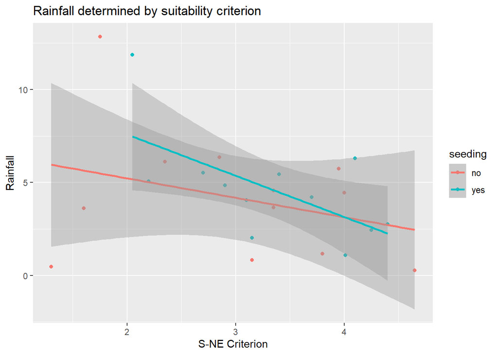

```r
ggplot(data=clouds, aes(x=sne, y=rainfall, col=seeding)) + geom_point() + geom_smooth(method='lm') + labs(title='Rainfall determined by suitability criterion',x='S-NE Criterion', y='Rainfall')
```

```r
cat("Now, fit a median regression (quantile regression) model")
```

```
## Now, fit a median regression (quantile regression) model
```

```r
median.reg <- rq(rainfall ~ sne, data = clouds, tau = 0.5)
cat("Summary of the model")
```

```
## Summary of the model
```

```r
summary(median.reg)
```

```
##
## Call: rq(formula = rainfall ~ sne, tau = 0.5, data = clouds)
##
## tau: [1] 0.5
##
## Coefficients:
##             coefficients lower bd upper bd
## (Intercept)  8.86133      3.14768 14.86666
## sne         -1.38667     -2.46926  0.13118
```

```r
cat("Summary of model with bootstrapped standard error")
```

```
## Summary of model with bootstrapped standard error
```

```r
summary(median.reg, se = "boot" )
```

```
##
## Call: rq(formula = rainfall ~ sne, tau = 0.5, data = clouds)
##
## tau: [1] 0.5
##
## Coefficients:
##             Value    Std. Error t value  Pr(>|t|)
## (Intercept)  8.86133  3.82416    2.31720  0.03019
## sne         -1.38667  1.11158   -1.24747  0.22534
```

```r
MSE.mrm <- mean((predict(median.reg, data = clouds, type = "response")-clouds$rainfall)^2)
cat("MSE of median regression Model: ",MSE.mrm)
```

```
## MSE of median regression Model:  7.722559
```

```r
cat("We can also plot this model to compare with previous linear model")
```

```
## We can also plot this model to compare with previous linear model
```

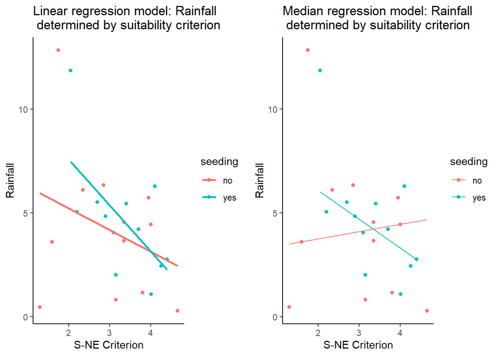

```r
plot_linear <- ggplot(data=clouds, aes(x=sne, y=rainfall, col=seeding)) + geom_point() + geom_smooth(method='lm',se=FALSE) + labs(title='Linear regression model: Rainfall\n determined by suitability criterion',x='S-NE Criterion', y='Rainfall') + theme_classic()


plot_median <- ggplot(data=clouds, aes(x=sne, y=rainfall, col=seeding)) + geom_point()  + labs(title='Median regression model: Rainfall\n determined by suitability criterion',x='S-NE Criterion', y='Rainfall') + stat_quantile(quantiles=c(0.50), method='rq') + theme_classic()

grid.arrange(plot_linear, plot_median, ncol=2)
```

In addition to fitting the the two models, I used graphical methods to compare a linear regression fit vs median regression fit. As shown in the plots, a median regression model on the data splits the absence of seeding in such a way that the median regression line has a positive slope, whereas, the simple linear regression model seems to have the negative slope. This indicates that there is higher variability in the rainfall data when cloud seeding is absent. Additionally, in presence of seeding, the median regression line is not weighted by the outliers, therefore seems better at explaining the overall data due to the high variability of the rainfall variable.

Now, we will reanalyze the ${\textbf{bodyfat}}$ data from the ${\textbf{TH.data}}$ package and compare the regression tree approach to median regression and summarize the different findings. Here, we will choose one independent variable. For the relationship between this variable and `DEXfat`, we will create linear regression quantile models for the 25%, 50% and 75% quantiles. We will then plot `DEXfat` vs that independent variable and plot the lines from the models on the graph.

```r
data("bodyfat")
head(bodyfat)
```

```
##    age DEXfat waistcirc hipcirc elbowbreadth kneebreadth anthro3a anthro3b
## 47  57  41.68     100.0   112.0          7.1         9.4     4.42     4.95
## 48  65  43.29      99.5   116.5          6.5         8.9     4.63     5.01
## 49  59  35.41      96.0   108.5          6.2         8.9     4.12     4.74
## 50  58  22.79      72.0    96.5          6.1         9.2     4.03     4.48
## 51  60  36.42      89.5   100.5          7.1        10.0     4.24     4.68
## 52  61  24.13      83.5    97.0          6.5         8.8     3.55     4.06
##    anthro3c anthro4
## 47     4.50    6.13
## 48     4.48    6.37
## 49     4.60    5.82
## 50     3.91    5.66
## 51     4.15    5.91
## 52     3.64    5.14
```

```r
ncol(bodyfat)
```

```
## [1] 10
```

```r
nrow(bodyfat)
```

```
## [1] 71
```

```r
library("rpart")
# ?bodyfat

cat("First, fit regression tree model")
```

```
## First, fit regression tree model
```

```r
#bodyfat_formula <- DEXfat ~ age + waistcirc + hipcirc + elbowbreadth + kneebreadth
bodyfat_rp  <- rpart(DEXfat ~ age + waistcirc + hipcirc + elbowbreadth + kneebreadth, data = bodyfat, control = rpart.control(minsplit=10))
summary(bodyfat_rp)
```

```
## Call:
## rpart(formula = DEXfat ~ age + waistcirc + hipcirc + elbowbreadth +
##     kneebreadth, data = bodyfat, control = rpart.control(minsplit = 10))
##   n= 71
##
##           CP nsplit  rel error    xerror       xstd
## 1 0.66289544      0 1.00000000 1.0368222 0.17140356
## 2 0.09376252      1 0.33710456 0.4157070 0.09468496
## 3 0.07703606      2 0.24334204 0.4443933 0.09093969
## 4 0.04507506      3 0.16630598 0.3588600 0.07358952
## 5 0.01844561      4 0.12123092 0.2973360 0.06264087
## 6 0.01818982      5 0.10278532 0.2747240 0.06357125
## 7 0.01000000      6 0.08459549 0.2655043 0.06376973
##
## Variable importance
##    waistcirc      hipcirc  kneebreadth elbowbreadth          age
##           34           30           24            7            4
##
## Node number 1: 71 observations,    complexity param=0.6628954
##   mean=30.78282, MSE=120.2251
##   left son=2 (40 obs) right son=3 (31 obs)
##   Primary splits:
##       waistcirc    < 88.4   to the left,  improve=0.6628954, (0 missing)
##       hipcirc      < 108.25 to the left,  improve=0.6254333, (0 missing)
##       kneebreadth  < 9.35   to the left,  improve=0.5142133, (0 missing)
##       age          < 40.5   to the left,  improve=0.1570344, (0 missing)
##       elbowbreadth < 6.55   to the left,  improve=0.1169918, (0 missing)
##   Surrogate splits:
##       hipcirc      < 107.85 to the left,  agree=0.915, adj=0.806, (0 split)
##       kneebreadth  < 9.35   to the left,  agree=0.831, adj=0.613, (0 split)
##       elbowbreadth < 6.55   to the left,  agree=0.648, adj=0.194, (0 split)
##       age          < 47     to the left,  agree=0.592, adj=0.065, (0 split)
##
## Node number 2: 40 observations,    complexity param=0.07703606
##   mean=22.92375, MSE=32.88394
##   left son=4 (17 obs) right son=5 (23 obs)
##   Primary splits:
##       hipcirc      < 96.25  to the left,  improve=0.4999238, (0 missing)
##       waistcirc    < 71.5   to the left,  improve=0.4408508, (0 missing)
##       kneebreadth  < 9.15   to the left,  improve=0.3123752, (0 missing)
```

[output cut: 66 more lines]

```
##
## Node number 9: 6 observations
##   mean=22.32833, MSE=5.242981
##
## Node number 10: 13 observations
##   mean=24.13077, MSE=9.046699
##
## Node number 11: 10 observations
##   mean=29.372, MSE=9.899016
##
## Node number 12: 13 observations
##   mean=35.27846, MSE=10.48431
##
## Node number 13: 15 observations
##   mean=42.71133, MSE=6.297998
```

```r
cat("Plot the regression tree model")
```

```
## Plot the regression tree model
```

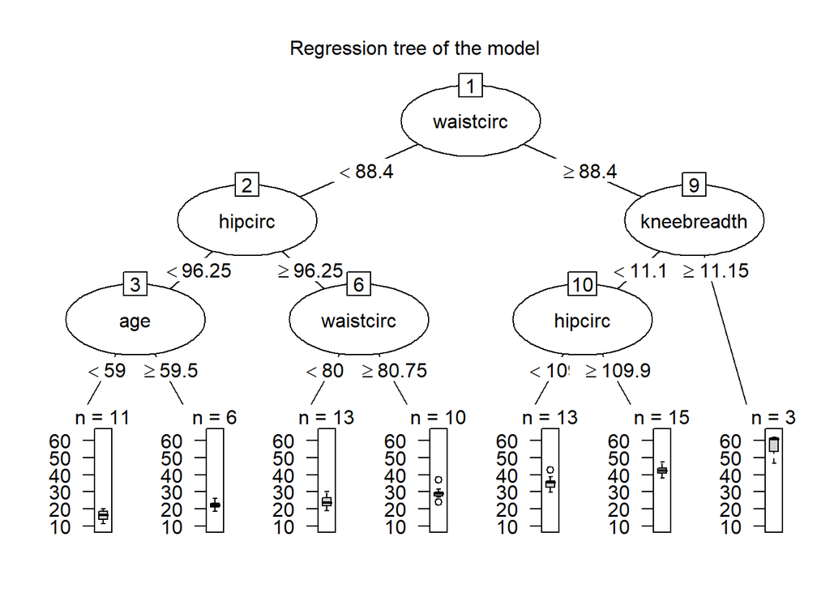

```r
library(partykit)
plot(as.party(bodyfat_rp), tp_args = list(id=FALSE), main = "Regression tree of the model")
```

```r
cat("Print CP-table")
```

```
## Print CP-table
```

```r
print(bodyfat_rp$cptable)
```

```
##           CP nsplit  rel error    xerror       xstd
## 1 0.66289544      0 1.00000000 1.0368222 0.17140356
## 2 0.09376252      1 0.33710456 0.4157070 0.09468496
## 3 0.07703606      2 0.24334204 0.4443933 0.09093969
## 4 0.04507506      3 0.16630598 0.3588600 0.07358952
## 5 0.01844561      4 0.12123092 0.2973360 0.06264087
## 6 0.01818982      5 0.10278532 0.2747240 0.06357125
## 7 0.01000000      6 0.08459549 0.2655043 0.06376973
```

```r
cat("CP value with lowest xerror")
```

```
## CP value with lowest xerror
```

```r
min.cp <- which.min(bodyfat_rp$cptable[,'xerror'])
min.cp
```

```
## 7
## 7
```

```r
cat(
  "We can fit the model\n using lowest xerror rate from CP for prunning tree model"
)
```

```
## We can fit the model
##  using lowest xerror rate from CP for prunning tree model
```

```r
#extract the lowest CP
cp <- bodyfat_rp$cptable[min.cp, 'CP']
bodyfat_prune <- prune(bodyfat_rp, cp=cp)

cat("Summary of the median regression model")
```

```
## Summary of the median regression model
```

```r
#Median Regression model
bodyfat_rpart_qrm <- rq(DEXfat ~ age + waistcirc + hipcirc + elbowbreadth + kneebreadth, data=bodyfat, tau = 0.50)
summary(bodyfat_rpart_qrm)
```

```
##
## Call: rq(formula = DEXfat ~ age + waistcirc + hipcirc + elbowbreadth +
##     kneebreadth, tau = 0.5, data = bodyfat)
##
## tau: [1] 0.5
##
## Coefficients:
##              coefficients lower bd  upper bd
## (Intercept)  -57.30032    -87.22119 -36.39320
## age            0.06839     -0.04338   0.14943
## waistcirc      0.28332      0.07991   0.48638
## hipcirc        0.51073      0.21307   0.75030
## elbowbreadth  -0.11982     -3.62882   2.18220
## kneebreadth    0.76453     -2.30145   2.33329
```

```r
bodyfat_rpart_qrm_summary <- summary(bodyfat_rpart_qrm)

#Predict Pruned regression tree model on the bodyfat data set
RegressionTree <- predict(bodyfat_prune, data=bodyfat)

#Create observed value and the predicted value
observed <- bodyfat$DEXfat
predict <- RegressionTree

#Regression.Tree MSE
RegressionTree.MSE <- mean((observed - predict)^2)

#Median Regression MSE
MedianRegression.MSE <- mean(bodyfat_rpart_qrm_summary$residuals^2)

df <- data.frame(
  RegressionTree.MSE,
  MedianRegression.MSE
)

cat("MSE of both models")
```

```
## MSE of both models
```

```r
df
```

```
##   RegressionTree.MSE MedianRegression.MSE
## 1            10.1705              15.0245
```

```r
cat("Based on this, pruned regression tree has lower MSE than median regression model")
```

```
## Based on this, pruned regression tree has lower MSE than median regression model
```

```r
cat("Plot based on the regression tree prunning")
```

```
## Plot based on the regression tree prunning
```

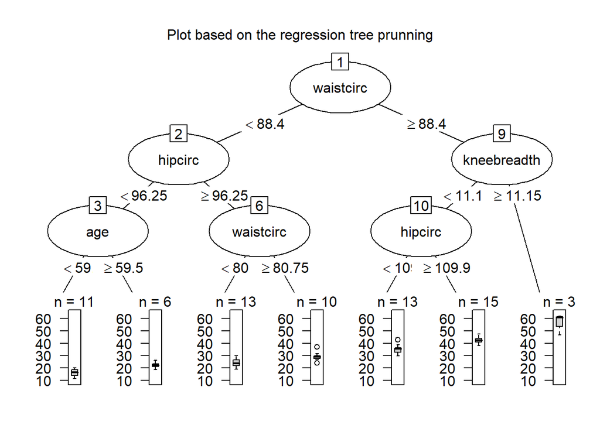

```r
plot(as.party(bodyfat_prune), tp_args = list(id=FALSE), main = "Plot based on the regression tree prunning")
```

```r
cat(
  "Based on the above pruned tree, the variables waist circumference and hip circumference splits explain the majority of the data and I will be choosing one of these variables for quantile regression."
)
```

```
## Based on the above pruned tree, the variables waist circumference and hip circumference splits explain the majority of the data and I will be choosing one of these variables for quantile regression.
```

```r
cat("Additionally, I will check with linear regression for the variable with significant effect")
```

```
## Additionally, I will check with linear regression for the variable with significant effect
```